# Assignment4

Ramya Sri Gautham:ramya.srigautham@rutgers.edu

2023-10-06

```r
#loading file and libraries
library(readxl)
library(forecast)
windDt <- read_excel('wind-power-production-us.xlsx')
```

###### *Extracting only wind power production in the USA column and period starting from 2016 to 2023 from the data set

```r
windDt$Quarter_Year <- as.Date(windDt$Quarter_Year)
filtered_data <- windDt[windDt$Quarter_Year >= as.Date('2016-01-01',) & windDt$Quarter_Year <= as.Date('2023-04-01',),]

#Time series data from 2016 to 2023
ts_data <- ts(filtered_data$Wind_United_States, start=c(2016), end=c(2023,2), frequency=4)
attributes(ts_data)
```

```
## $tsp
## [1] 2016.00 2023.25    4.00
##
## $class
## [1] "ts"
```

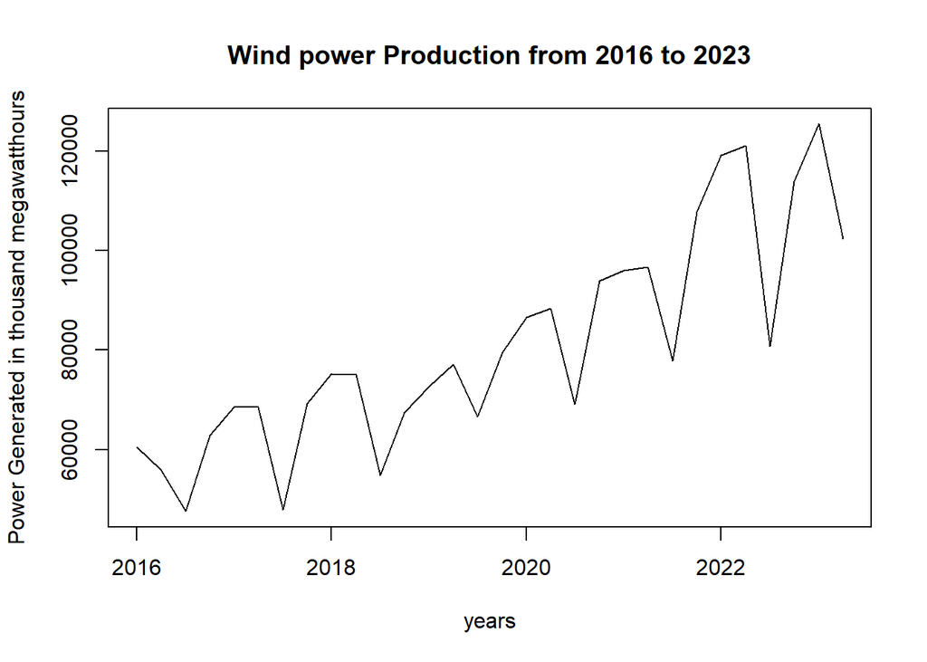

```r
plot(ts_data, main='Wind power Production from 2016 to 2023', xlab='years', ylab='Power Generated in thousand megawatthours')
```

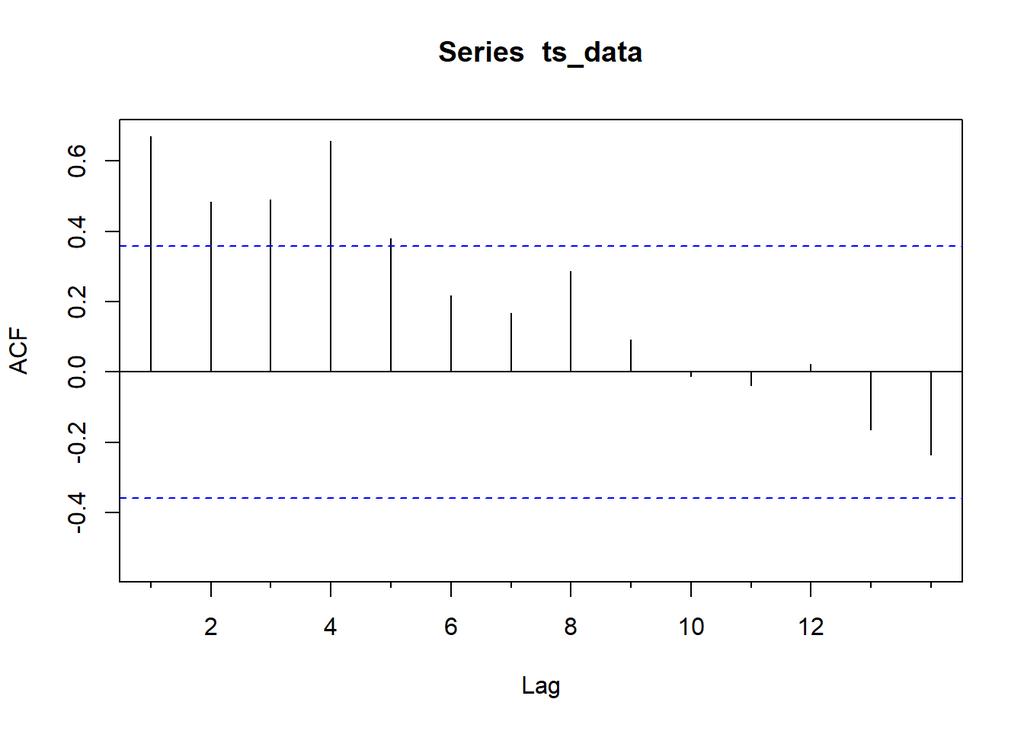

```r
Acf(ts_data) #Acf plot
```

##### According to the analysis of ACF, if the plot shows large and positive autocorrelations for small lags then the data shows signs of a particular trend and if the autocorrelations are larger for seasonal lags then the data shows signs of seasonality. From the given plot it is evident that the data in discussion shows signs of both trend and seasonality.

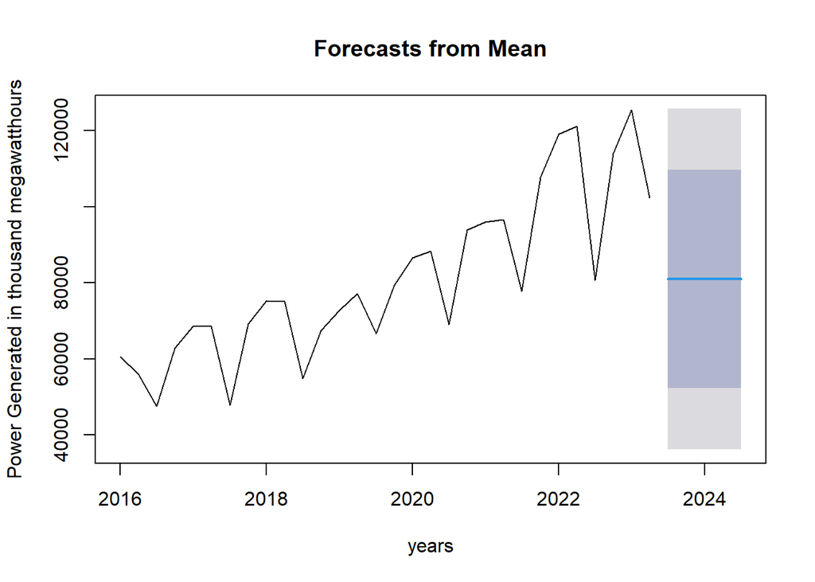

```r
#take Mean of all available history
mean_forecast <- meanf(ts_data,5)
plot(mean_forecast, xlab='years', ylab='Power Generated in thousand megawatthours')
```

##### Since the mean of the data is **80953.1**, the expectation of the forecast based on mean should be spaced around that value and plot justifies the expectation.

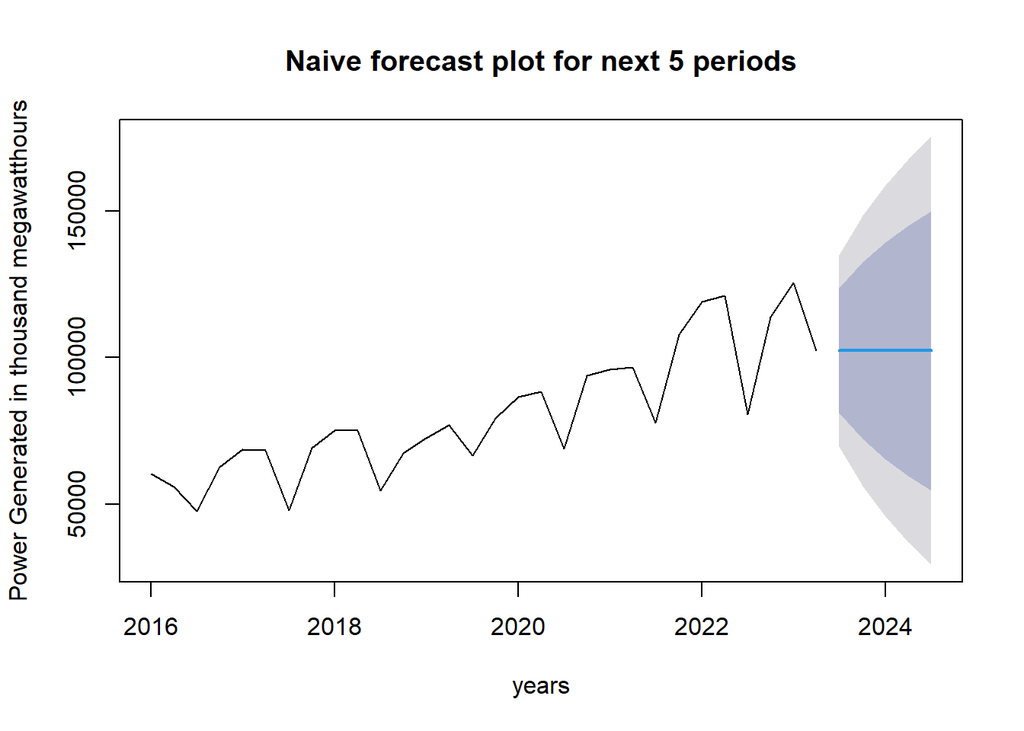

```r
# Naive
naive_forecast <- naive(ts_data,5)
plot(naive_forecast , main='Naive forecast plot for next 5 periods', xlab='years', ylab='Power Generated in thousand megawatthours')
```

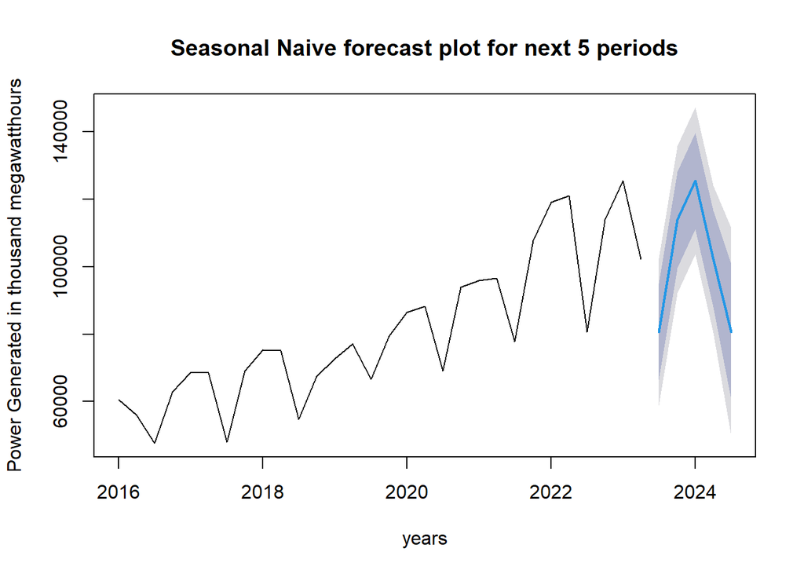

```r
# Random Walk
rwf_forecast <- rwf(ts_data,5)
rwf_forecast <- rwf(ts_data,5, drift=TRUE)
# Seasonal Naive
snaive_forecast<- snaive(ts_data,5)
plot(snaive_forecast , main='Seasonal Naive forecast plot for next 5 periods', xlab='years', ylab='Power Generated in thousand megawatthours')
```

##### A seasonal naive forecast is a simple time series forecasting method where the forecast for a future period is based on the observed value from the same season in the previous year. Since our data has seasonality, the forecast of the next 5 quarters would be a projection based on the previous quarters from the point of observation and our plot justifies the same. Note that this projection does not considers the influence of trend in our data and hence would not be a best fit for our solution.

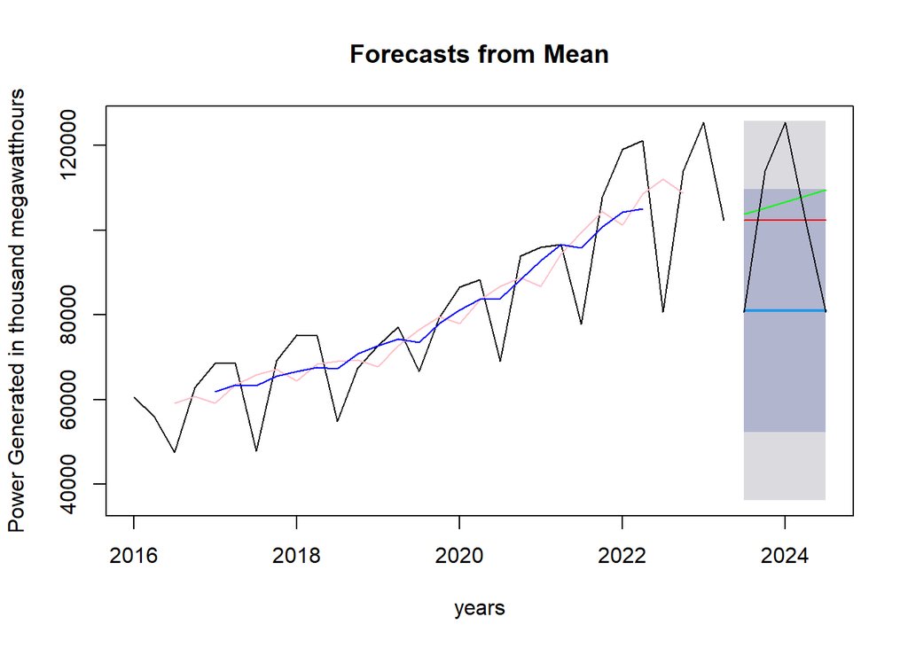

```r
# Moving Averages
MVA5_forecast <- ma(ts_data,order=5)
MVA9_forecast <- ma(ts_data,order=9)

# plot all in a single chart
plot(mean_forecast, xlab='years', ylab='Power Generated in thousand megawatthours')
lines(naive_forecast$mean,col="red")
lines(rwf_forecast$mean,col="green")
lines(snaive_forecast$mean,col="black")
lines(MVA5_forecast,col="Pink")
lines(MVA9_forecast,col="Blue")
```

##### Random walk forecast or Drift method is a variation of the naive method that allows the forecasts to increase or decrease overtime, where the amount of change overtime (drift) is the average change seen historically. That means the value of the next 5 forecasts would depend only the last observation **102354** added with the value of drift at each level of observation.Also from the plots of Moving Averagers of orders 5 and 9 we can remove the seasonality components and we can cleary see that the data has a **Linear Additive Trend**.

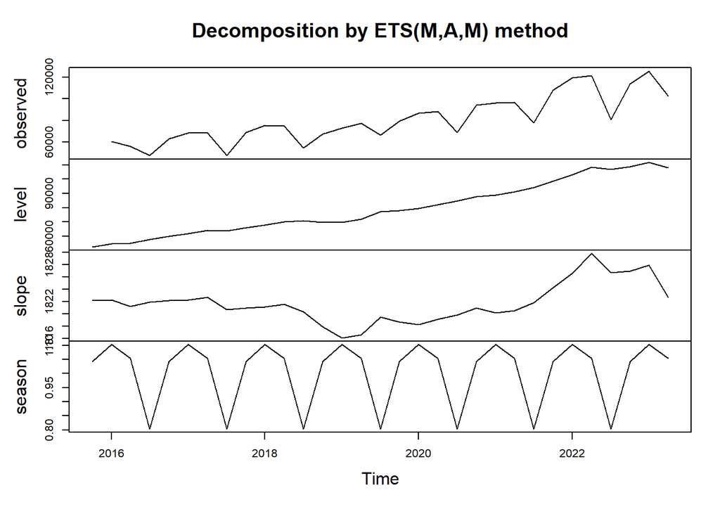

```r
# Decomposition
ets_forecast <- ets(ts_data)
plot(ets_forecast)
```

##### From the decomposition of the data using the ETS function, we can see that the model that was automatically chosen was ETS(M,A,M). This would mean that the data has multiplication error, Additive Trend and Multiplicative Seasonality. Judging by the plot, we can see that the growth of the trend is quite linear and not exponential which would mean that it is additive. And the size of the growth of seasonality increases over time especially from years 2020 to 2023.

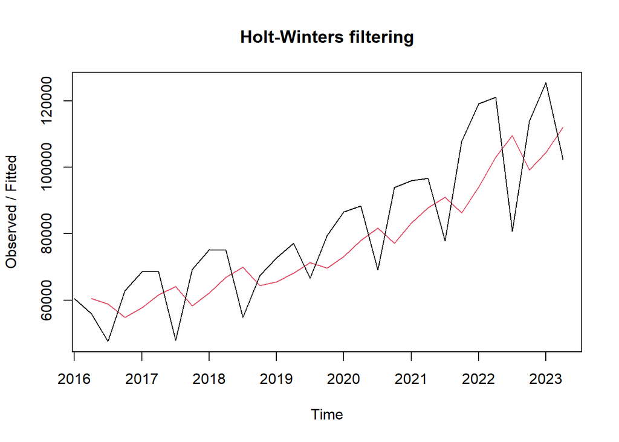

```r
# HoltWinters
SSE_Simple <- HoltWinters(ts_data,beta=FALSE,gamma=FALSE)
sseforecast <- forecast:::forecast.HoltWinters(SSE_Simple,h=5)
plot(SSE_Simple)
```

##### From the decomposition analysis, we can clearly see that there is noticable influence of trend and seasonality. Hence simple smoothing equations method would not be the correct method for our forecasting as it negelects the trend and seasonality components. The resulting plots proves the same analysis.

```r
HW_forecast <- HoltWinters(ts_data)
holtforecast <- forecast:::forecast.HoltWinters(HW_forecast,h=5)
HW_forecast
```

```
## Holt-Winters exponential smoothing with trend and additive seasonal component.
##
## Call:
## HoltWinters(x = ts_data)
##
## Smoothing parameters:
##  alpha: 0.2335362
##  beta : 0
##  gamma: 0.4162918
##
## Coefficients:
##          [,1]
## a  106274.030
## b    1670.887
## s1 -17123.853
## s2   7721.194
## s3  13643.214
## s4   4358.748
```

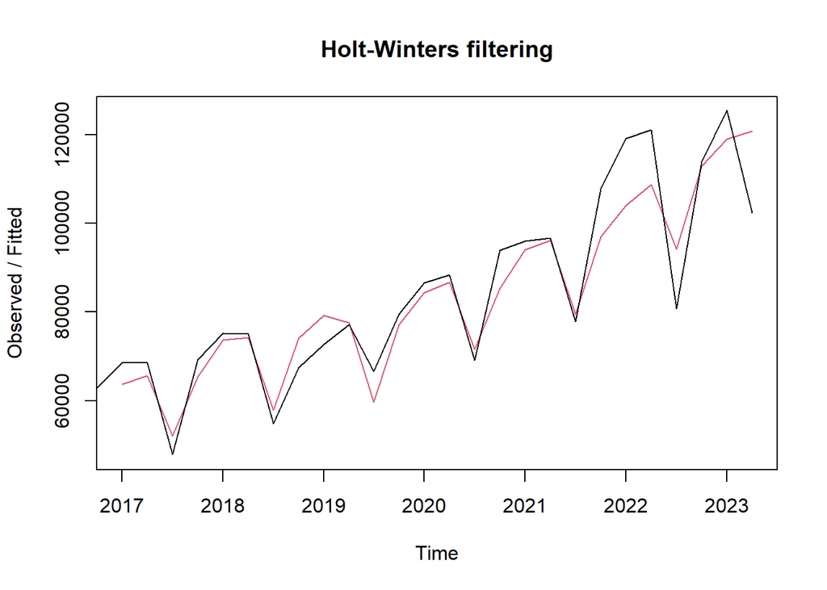

```r
plot(HW_forecast)
```

##### Finally we come to Holt-Winters method which incorporates with both trend and seasonal components. First we try by using the default function which results in the model selecting smoothing with trend and additive seasonal component. This would not yeild the best results as we found from previous analysis that the best fit for our model would be with multiplicative component for seasonality.

```r
HW_forecastmult <- HoltWinters(ts_data , seasonal = "multiplicative")
holtforecastmult <- forecast:::forecast.HoltWinters(HW_forecastmult,h=5)
HW_forecastmult
```

```
## Holt-Winters exponential smoothing with trend and multiplicative seasonal component.
##
## Call:
## HoltWinters(x = ts_data, seasonal = "multiplicative")
##
## Smoothing parameters:
##  alpha: 0.4639175
##  beta : 0
##  gamma: 0
##
## Coefficients:
##            [,1]
## a  1.055784e+05
## b  1.670887e+03
## s1 8.109038e-01
## s2 1.025131e+00
## s3 1.089395e+00
## s4 1.074570e+00
```

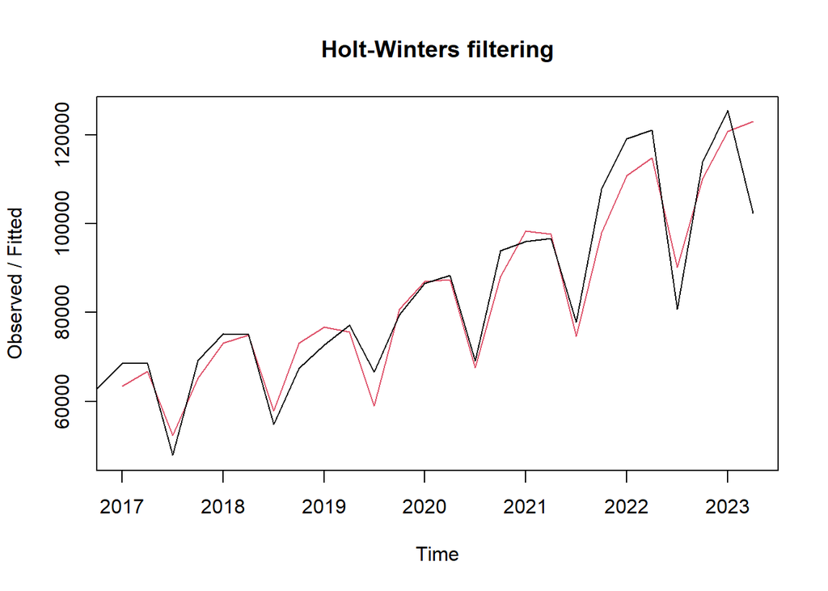

```r
plot(HW_forecastmult)
```

##### Now we can change the sesonality to be multiplicative and see how that helps in forecasting. From the plot we can see that this is a better fit than the additive seasonality plot.

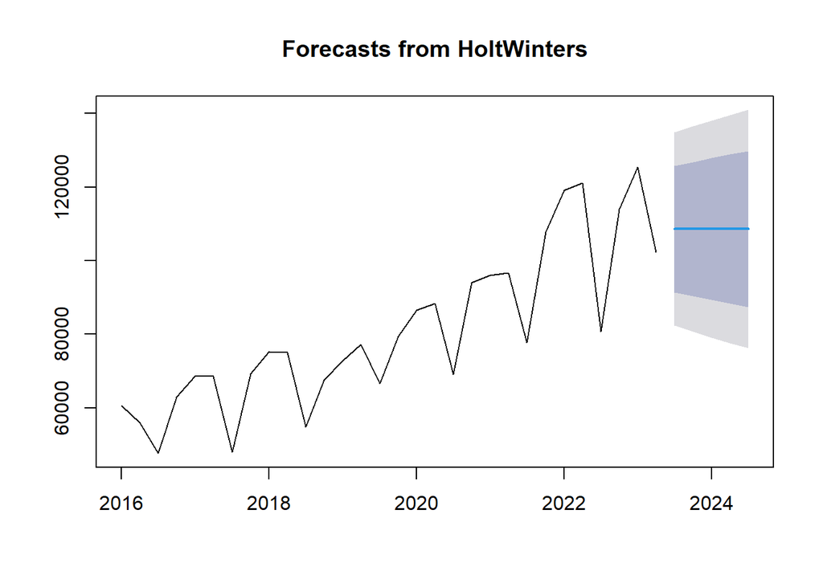

```r
#Forecast
plot(sseforecast)
```

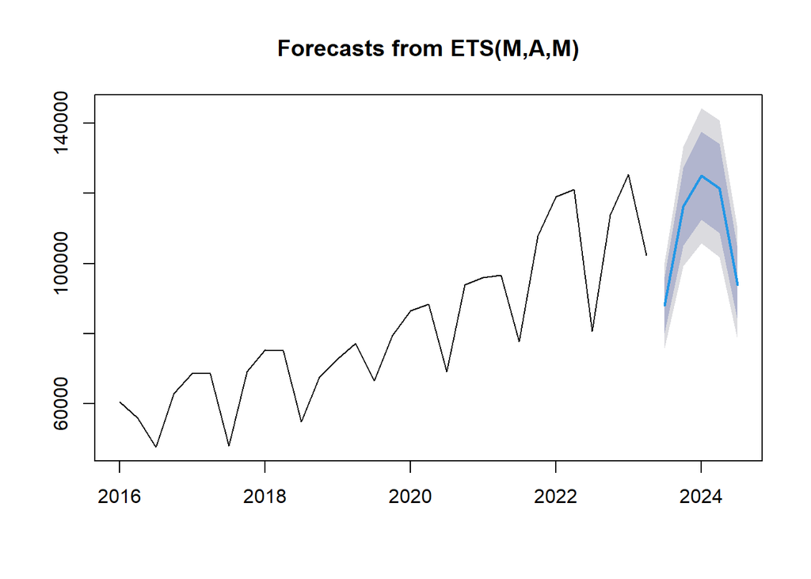

```r
forecast_ets <- forecast.ets(ets_forecast, h=5)
plot(forecast_ets)
```

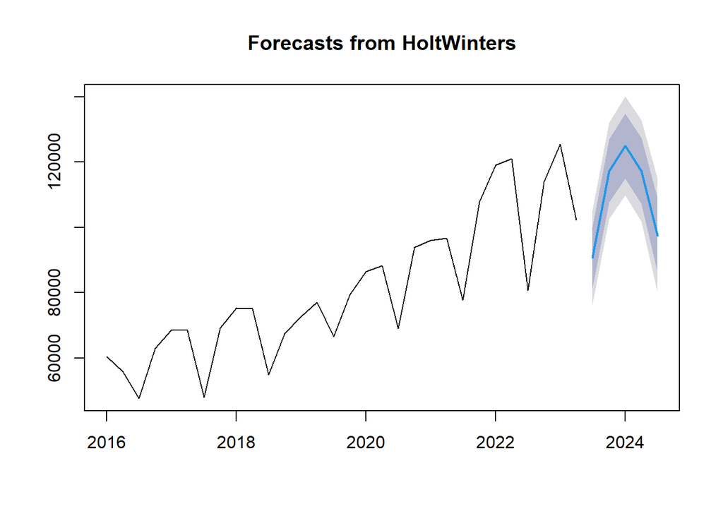

```r
plot(holtforecast)
```

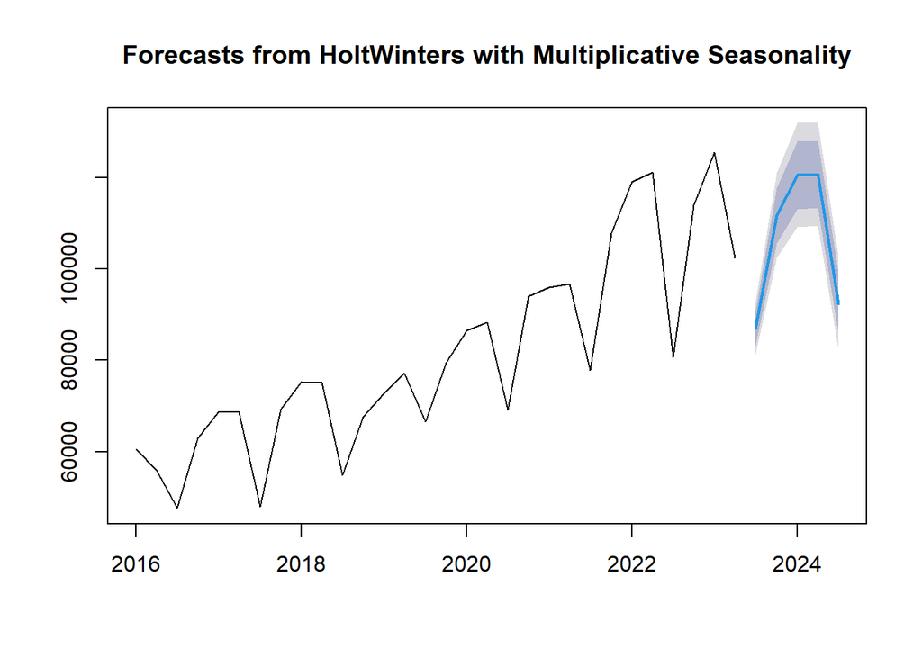

```r
plot(holtforecastmult, main = "Forecasts from HoltWinters with Multiplicative Seasonality")
```

##### For all the different types of forecasts, we can see that Holt-Winters forecasting with multiplicative seasonality and normal exponential smoothing methods give the best forecasting results for our data.

```r
#Final Results
summary(sseforecast)
```

```
##
## Forecast method: HoltWinters
##
## Model Information:
## Holt-Winters exponential smoothing without trend and without seasonal component.
##
## Call:
## HoltWinters(x = ts_data, beta = FALSE, gamma = FALSE)
##
## Smoothing parameters:
##  alpha: 0.3614497
##  beta : FALSE
##  gamma: FALSE
##
## Coefficients:
##       [,1]
## a 108556.3
##
## Error measures:
##                    ME     RMSE      MAE     MPE     MAPE     MASE       ACF1
## Training set 4580.435 13938.25 12616.09 3.20239 15.69802 1.358879 -0.1565421
##
## Forecasts:
##         Point Forecast    Lo 80    Hi 80    Lo 95    Hi 95
## 2023 Q3       108556.3 91387.16 125725.4 82298.37 134814.2
## 2023 Q4       108556.3 90300.04 126812.6 80635.77 136476.8
## 2024 Q1       108556.3 89274.12 127838.5 79066.75 138045.9
## 2024 Q2       108556.3 88300.08 128812.5 77577.09 139535.5
## 2024 Q3       108556.3 87370.79 129741.8 76155.86 140956.7
```

```r
#Final Results
summary(holtforecast)
```

```
##
## Forecast method: HoltWinters
##
## Model Information:
## Holt-Winters exponential smoothing with trend and additive seasonal component.
##
## Call:
## HoltWinters(x = ts_data)
##
## Smoothing parameters:
##  alpha: 0.2335362
##  beta : 0
##  gamma: 0.4162918
##
## Coefficients:
##          [,1]
## a  106274.030
## b    1670.887
## s1 -17123.853
## s2   7721.194
## s3  13643.214
## s4   4358.748
##
## Error measures:
##                    ME     RMSE      MAE       MPE     MAPE      MASE       ACF1
## Training set 1036.574 7267.038 5417.555 0.5521231 6.254733 0.5835247 0.04792459
##
## Forecasts:
##         Point Forecast     Lo 80    Hi 80     Lo 95    Hi 95
## 2023 Q3       90821.06  81420.66 100221.5  76444.39 105197.7
## 2023 Q4      117337.00 107683.65 126990.3 102573.48 132100.5
## 2024 Q1      124929.91 115030.08 134829.7 109789.43 140070.4
## 2024 Q2      117316.33 107176.01 127456.6 101808.05 132824.6
## 2024 Q3       97504.61  86111.13 108898.1  80079.79 114929.4
```

```r
#Final Results
summary(holtforecastmult)
```

```
##
## Forecast method: HoltWinters
##
## Model Information:
## Holt-Winters exponential smoothing with trend and multiplicative seasonal component.
##
## Call:
## HoltWinters(x = ts_data, seasonal = "multiplicative")
##
## Smoothing parameters:
##  alpha: 0.4639175
##  beta : 0
##  gamma: 0
##
## Coefficients:
##            [,1]
## a  1.055784e+05
## b  1.670887e+03
## s1 8.109038e-01
## s2 1.025131e+00
## s3 1.089395e+00
## s4 1.074570e+00
##
## Error measures:
##                    ME     RMSE     MAE       MPE    MAPE      MASE        ACF1
## Training set 537.2662 6215.461 4584.97 0.2871016 5.41041 0.4938469 -0.00335275
##
## Forecasts:
##         Point Forecast     Lo 80     Hi 80     Lo 95    Hi 95
## 2023 Q3       86968.88  83214.49  90723.26  81227.05  92710.7
## 2023 Q4      111657.45 105605.84 117709.07 102402.31 120912.6
## 2024 Q1      120477.36 113030.69 127924.03 109088.66 131866.1
## 2024 Q2      120633.39 113288.06 127978.73 109399.67 131867.1
## 2024 Q3       92388.59  85693.79  99083.39  82149.77 102627.4
```

```r
#Final Results
summary(forecast_ets)
```

```
##
## Forecast method: ETS(M,A,M)
##
## Model Information:
## ETS(M,A,M)
##
## Call:
##  ets(y = ts_data)
##
##   Smoothing parameters:
##     alpha = 0.3469
##     beta  = 3e-04
##     gamma = 1e-04
##
##   Initial states:
##     l = 52680.7818
##     b = 1822.1398
##     s = 1.0415 0.8028 1.0535 1.1022
##
##   sigma:  0.0708
##
##      AIC     AICc      BIC
## 628.0383 637.0383 640.6491
##
## Error measures:
##                    ME     RMSE      MAE        MPE     MAPE      MASE
## Training set 83.22643 5453.353 3964.498 -0.3506842 4.840725 0.4270159
##                    ACF1
## Training set 0.08159006
##
## Forecasts:
##         Point Forecast     Lo 80     Hi 80     Lo 95    Hi 95
## 2023 Q3       88099.69  80105.64  96093.74  75873.85 100325.5
## 2023 Q4      116202.25 105057.21 127347.29  99157.38 133247.1
## 2024 Q1      124979.03 112396.28 137561.77 105735.38 144222.7
## 2024 Q2      121379.87 108622.07 134137.68 101868.49 140891.2
## 2024 Q3       93952.41  83688.59 104216.23  78255.26 109649.6
```

##### In model selection, the goal is typically to choose the model that provides the most accurate forecasts. RMSE is a better choice for this purpose because it provides a more accurate representation of forecasting errors, taking both magnitude and direction into account. Lower RMSE values indicate better forecasting performance. From the Analysis of RMSE of the four given models we can see that RMSE of **SSE > HoltWinters > HoltWinters(Multi) > ETS** . Hence Exponential Smoothing State Space (ETS) is the best model for forecasting for our data.